# Changing Signal Task Analysis

This document is a companion to our submission to the 2020 Artificial Life conference, ‘Genetic regulation facilitates the evolution of signal-response plasticity in digital organisms’. Here, we give an overview of the changing signal diagnostic task (mirroring the overview given in the paper), and we provide our data analyses for related experiments. All of our source code for statistical analyses and data visualizations is embedded in this document. Please [file an issue or make a pull request on github](https://github.com/amlalejini/ALife-2020--SignalGP-Genetic-Regulation/issues) to report any mistakes or request more explanation.

## Overview

```r
# Experimental parameters referenced in-text all in one convenient place.
time_steps <- 128
replicates <- 200
population_size <- 1000
generations <- 10000
env_complexities <- c(16)
```

The changing signal task requires organisms to express a unique response for each of $K$ distinct environmental signals (i.e., each signal has a distinct tag); the figure below is given as an example. Because signals are distinct, organisms do not need to alter their responses to particular signals over time. Instead, organisms may ‘hardware’ each of the $K$ possible responses to the appropriate environmental signal. However, environmental signals are presented in a random order; thus, the correct *order* of responses will vary and cannot be hardcoded. As in the repeated signal task, organisms respond by executing one of $K$ response instructions. Otherwise, evaluation (and fitness assignment) on the changing signal task mirrors that of the repeated signal task.

[figure not shown]

changing-signal-task-overview

Requiring organisms to express a distinct instruction in response to each environmental signal represents organisms having to perform distinct behaviors.

We allowed organisms 128 time steps to express the appropriate response after receiving an environmental signal. Once the allotted time to respond expires or the organism expresses any response, the organism’s threads of execution are reset, resulting in a loss of all thread-local memory. *Only* the contents of an organism’s global memory and each function’s regulatory state persist. The environment then produces the next signal (distinct from all previous signals) to which the organism may respond. An organism’s fitness is equal to the number of correct responses expressed during evaluation.

We evolved populations of 1000 SignalGP organisms to solve the changing signal task at $K=16$ (where $K$ denotes the number of environmental signals). We evolved populations for 10^{4} generations or until an organism capable of achieving a perfect score during task evaluation (i.e., able to express the appropriate response to each of the $K$ signals) evolved.

We ran 200 replicate populations (each with a distinct random number seed) of each of two experimental conditions:

1. a regulation-augmented treatment where organisms have access to genetic regulation.
2. a regulation-disabled treatment where organisms do not have access to genetic regulation.

Note this task does not require organisms to shift their response to particular signals over time, and as such, genetic regulation is unnecessary. Further, because organisms experience environmental signals in a random order, erroneous genetic regulation can manifest as cryptic variation. For example, non-adaptive down-regulation of a particular response function may be neutral given one sequence of environmental signals, but may be deleterious in another. **We expected regulation-enabled SignalGP to exhibit non-adaptive plasticity, potentially resulting in slower adaptation and non-general solutions.**

## Analysis Dependencies

Load all required R libraries.

```r
library(ggplot2)  # (Wickham, 2009)
library(dplyr)    # (Wickham et al., 2018)
library(cowplot)  # (Wilke, 2018)
library(viridis)  # (Garnier, 2018)
```

These analyses were conducted in the following computing environment:

```r
print(version)
```

```
##                _
## platform       x86_64-apple-darwin15.6.0
## arch           x86_64
## os             darwin15.6.0
## system         x86_64, darwin15.6.0
## status
## major          3
## minor          6.2
## year           2019
## month          12
## day            12
## svn rev        77560
## language       R
## version.string R version 3.6.2 (2019-12-12)
## nickname       Dark and Stormy Night
```

## Setup

Load data, initial data cleanup, configure some global settings.

```r
data_loc <- "../data/balanced-reg-mult/chg-env/max_fit_orgs.csv"
data <- read.csv(data_loc, na.strings="NONE")

# Specify factors (not all of these matter for this set of runs).
data$matchbin_thresh <-
  factor(data$matchbin_thresh,
         levels=c(0, 25, 50, 75))
data$NUM_ENV_STATES <-
  factor(data$NUM_ENV_STATES,
         levels=c(2, 4, 8, 16, 32))
data$NUM_ENV_UPDATES <-
  factor(data$NUM_ENV_UPDATES,
         levels=c(2, 4, 8, 16, 32))
data$TAG_LEN <-
  factor(data$TAG_LEN,
         levels=c(32, 64, 128))

# Define function to summarize regulation/memory configurations.
get_con <- function(reg, mem) {
  if (reg == "0" && mem == "0") {
    return("none")
  } else if (reg == "0" && mem=="1") {
    return("memory")
  } else if (reg=="1" && mem=="0") {
    return("regulation")
  } else if (reg=="1" && mem=="1") {
    return("both")
  } else {
    return("UNKNOWN")
  }
}
# Specify experimental condition for each datum.
data$condition <- mapply(get_con,
                         data$USE_FUNC_REGULATION,
                         data$USE_GLOBAL_MEMORY)
data$condition <- factor(data$condition,
                         levels=c("regulation", "memory", "none", "both"))

# A lookup table for task complexities
task_label_lu <- c(
  "2" = "2-signal task",
  "4" = "4-signal task",
  "8" = "8-signal task",
  "16" = "16-signal task",
  "32" ="32-signal task"
)

# Settings for statistical analyses.
alpha <- 0.05
correction_method <- "bonferroni"

# Configure our default graphing theme
theme_set(theme_cowplot())
```

## Does regulation hinder the evolution of successful genotypes?

Here, we look at the number of solutions evolved with access and without access to genetic regulation. An organism is categorized as a ‘solution’ if it can correctly respond in each of the $K$ environmental signals *during evaluation*.

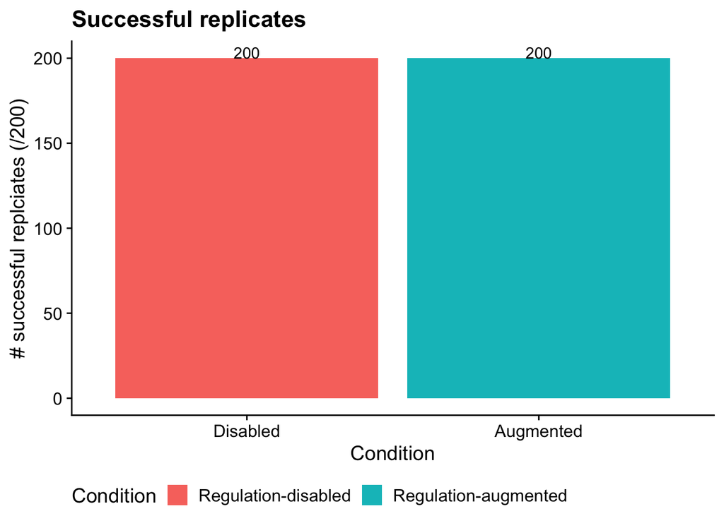

```r
# Filter data to include only replicates labeled as solutions
sol_data <- filter(data, solution=="1")
# Graph the number of solutions evolved in each condition, faceted by environmental complexity
ggplot(sol_data, aes(x=condition, fill=condition)) +
  geom_bar() +
  geom_text(stat="count",
            mapping=aes(label=..count..),
            position=position_dodge(0.9), vjust=0) +
  scale_x_discrete(name="Condition",
                   breaks=c("memory","both"),
                   labels=c("Disabled",
                            "Augmented")) +
  scale_fill_discrete(name="Condition",
                      breaks=c("memory", "both"),
                      labels=c("Regulation-disabled",
                               "Regulation-augmented")) +
  ylab("# successful replciates (/200)") +
  theme(legend.position = "bottom") +
  ggtitle("Successful replicates")
```

Programs capable of achieving a perfect score on the changing signal task (for a given sequence of environment signals) evolve in all 200 replicates of each condition (i.e., with and without access to genetic regulation). These programs, however, do not necessarily generalize across all possible sequences of environmental signals.

### Does access to regulation slow adaptation?

I.e., did successful programs take longer (more generations) to evolve than those evolved in the regulation-disabled treatment?

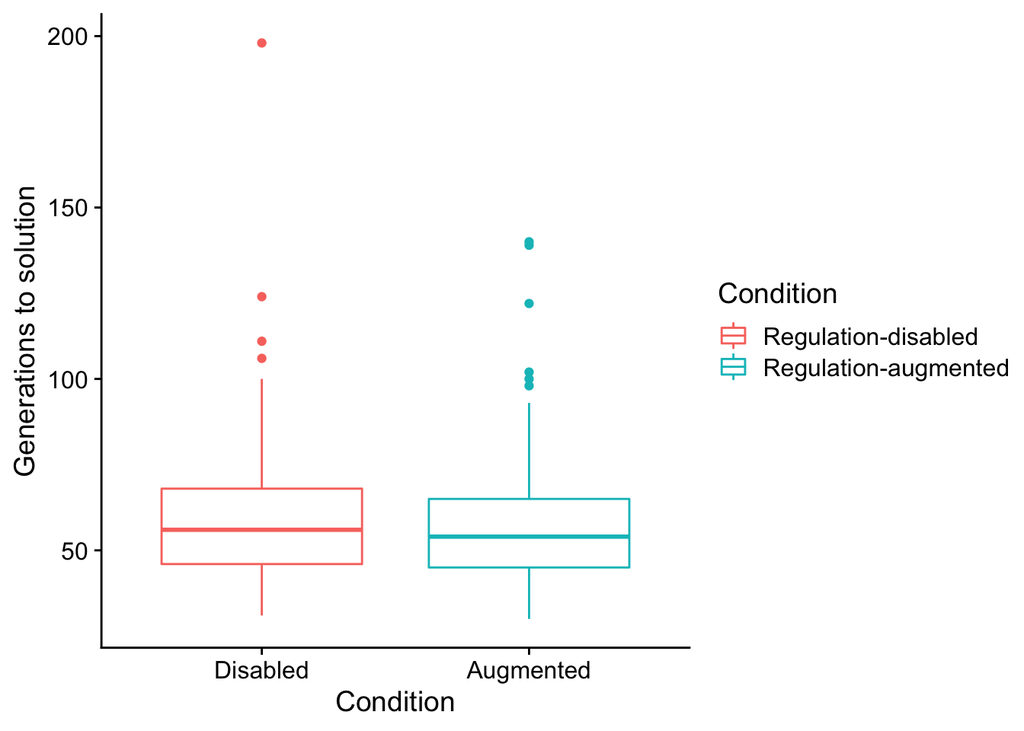

```r
ggplot(data, aes(x=condition, y=update, color=condition)) +
  geom_boxplot() +
  scale_x_discrete(name="Condition",
                 breaks=c("memory","both"),
                 labels=c("Disabled",
                          "Augmented")) +
  scale_color_discrete(name="Condition",
                       breaks=c("memory", "both"),
                       labels=c("Regulation-disabled",
                                "Regulation-augmented")) +
  ylab("Generations to solution")
```

```r
print(wilcox.test(formula=update~condition, data=data, exact=FALSE, conf.int=TRUE))
```

```
##
##  Wilcoxon rank sum test with continuity correction
##
## data:  update by condition
## W = 21596, p-value = 0.1676
## alternative hypothesis: true location shift is not equal to 0
## 95 percent confidence interval:
##  -0.9999577  4.9999678
## sample estimates:
## difference in location
##               2.000068
```

We find no evidence (Wilcoxon rank-sum test) that access to regulation resulted in slower adaptation.

### Do they generalize?

Note that solutions may or may not generalize beyond the sequence of environmental signals on which they achieved a perfect score (and were thus categorized as a ‘solution’). We re-evaluated each ‘solution’ on a random sample of 5000 sequences of environmental signals to test for generalization. We deem organisms as having successfully generalized only if they responded correctly in all 5000 tests. Additionally, we measured generalization in the regulation-augmented condition with regulation knocked out.

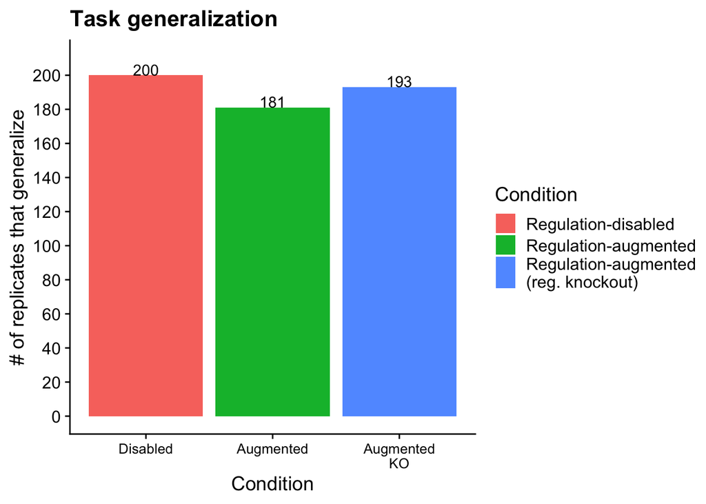

```r
# Grab count data to make bar plot life easier
num_solutions_reg <-
  length(filter(data, condition=="both" & solution=="1")$SEED)
num_generalize_reg <-
  length(filter(data, condition=="both" & all_solution=="1")$SEED)
num_generalize_ko_reg <-
  length(filter(data, condition=="both" & all_solution_ko_reg=="1")$SEED)

num_generalize_mem <-
  length(filter(data, condition=="memory" & all_solution=="1")$SEED)

sol_cnts <- data.frame(x=1:3)
sol_cnts$type <- c("reg_generalize", "reg_generalize_ko_reg", "mem_generalize")
sol_cnts$val <- c(num_generalize_reg, num_generalize_ko_reg, num_generalize_mem)

ggplot(sol_cnts, aes(x=type, y=val, fill=type)) +
  geom_bar(stat="identity") +
  geom_text(aes(label=val),
            stat="identity",
            position=position_dodge(0.75), vjust=-0.01) +
  scale_x_discrete(name="Condition",
                   limits=c("mem_generalize",
                            "reg_generalize",
                            "reg_generalize_ko_reg"),
                   labels=c("Disabled",
                            "Augmented",
                            "Augmented\nKO")) +
  scale_fill_discrete(name="Condition",
                      limits=c("mem_generalize",
                               "reg_generalize",
                               "reg_generalize_ko_reg"),
                      labels=c("Regulation-disabled",
                               "Regulation-augmented",
                               "Regulation-augmented\n(reg. knockout)")) +
  scale_y_continuous(name="# of replicates that generalize",
                     limits=c(0, 210),
                     breaks=seq(0,200,20)) +
  theme(legend.position="right",
        axis.text.x = element_text(size=10)) +
  ggtitle("Task generalization")
```

```r
  ggsave("./imgs/chg-env-16-generalization.png", width=6,height=4)
```

All programs evolved without access to regulation successfully generalized. However, 19 out of 200 solutions evolved with access to regulation failed to generalize (statistically significant, Fisher’s exact test).

```r
table <- matrix(c(num_generalize_reg,
                  num_generalize_mem,
                  replicates - num_generalize_reg,
                  replicates - num_generalize_mem),
                nrow=2)
rownames(table) <- c("reg-augmented", "reg-disabled")
colnames(table) <- c("success", "fail")
fisher.test(table)
```

```
##
##  Fisher's Exact Test for Count Data
##
## data:  table
## p-value = 2.436e-06
## alternative hypothesis: true odds ratio is not equal to 1
## 95 percent confidence interval:
##  0.0000000 0.1982563
## sample estimates:
## odds ratio
##          0
```

Moreover, 12 of the 19 non-generalizing programs generalize when we knockout genetic regulation. Upon close inspection, the other 7 non-general programs relied on genetic regulation to achieve initial success but failed to generalize to artitrary environment signal sequences.